# YoFitBot

Shiv

Sunday, September 27, 2015

YoFitBot, **Yo**ur personal **Fit**ness training **Bot**, monitors your excercise and provide real time supervision and grading of your excercise routine. FitBot is trained using state of art machine learning algorithms and uses training data made avaialble by [groupware.les](http://groupware.les.inf.puc-rio.br/har) . This paper describes the buliding of the YoFitBot. Note that this work is done as project assignment for the fabulous Machine Learning Course from John Hopkins ( provided via Coursera). For more details check [John Hopkins Data Science Specialization](https://www.coursera.org/specializations/jhudatascience)

The data is available as Training and Validation Set. The prediction here is **classe** variable, that grades the training as “A”, “B”, “C”, “D”, “E”. Training Set [Provided TrainingData](https://d396qusza40orc.cloudfront.net/predmachlearn/pml-training.csv) contains the complete data, while the validation set [Provided Validation Data](https://d396qusza40orc.cloudfront.net/predmachlearn/pml-testing.csv) contains the predictors/feature variables but does not disclose the classe variable (the prediction). The validation set is considered out of sample data and is used to check the model in real world conditions. Results from the validation test are scored with a max of 2 trials allowd to get the results right.

Training of YoFitBot uses the following steps. Each of the steps is detailed in sections that follow.

- Data loading and Training and Test Set creation
- Data cleaning and creation of Training and Test Sets
- Exploratory data analysis to identify features and PCA to reduce dimensionality
- Training multiple Models
- Evaluating Model accuracy using cross validation
- Applying the best models to Validation set and check accuracy score on out of sample data

The following sections details on the bulding of the machine learning algoritms and princples.

## Data Cleaning and Creation of Training and Test Sets

A read out of the data and few observations made

- There are 3 type of variables - int, num and factors. Note : Factor variables need to be covereted before any applicaiton.
- Lots of variables seem are NA. Would be intresting to explore columns that are sparse to the extend they could be removed.

The data is split as initial training and test set that are they cleaned. From 19622 rows of original data, the training set consist of 7850 rows and testSet contains 11772 rows of data now.

Of the 160 features in the training data set there are 67 features that have on an average have 97.96% their values as *NAs*. These are very sparse colums and not very usable to be used as a predictors. Does the validation set shows the same pattern? Of the 160 features in the validation data set there are 100 features that have 100% of their values as *NAs*. This basically implies that 100 can be dropped from the training and test sets. For a list of columns that are dropped refer Appendix “Dropped feature”. Dropping these columns we have removed features in the training set that are not valid feature ( do not have values) in the real world data and thus would have no impact on the prediction.

Post processing ( removal of sparse cols) the training set has a total of 53 features of which 53 features which are 100% dense ( i.e. have 100% non NA values). The same processing is applied to Test and Validation Set.

The Training data is split into 11 diffirent subsets that are they used to arrive at the final Training and Test Sets. Multiple training and test subsets are identified to introduce cross validtion and thus reduce overfitting models. Of the 11 sets, 3 would be used to train the models and 8 are retained as tests set.

The 3 training set, called *trainingSubSet1*, *trainingSubSet2* and *trainingSubSet3*, have 7850, 1175 and 1179 respectively.

The 8 test, called *testSubSet1* .. *testSubSet8*, have 1177, 1176, 1178 1177, 1178, 1177, 1177 and 1178 rows respectively.

## Exploratory data analysis to identify features and PCA to reduce dimensionality

Explore feature that show high correlation to see these how these influence the predictor.

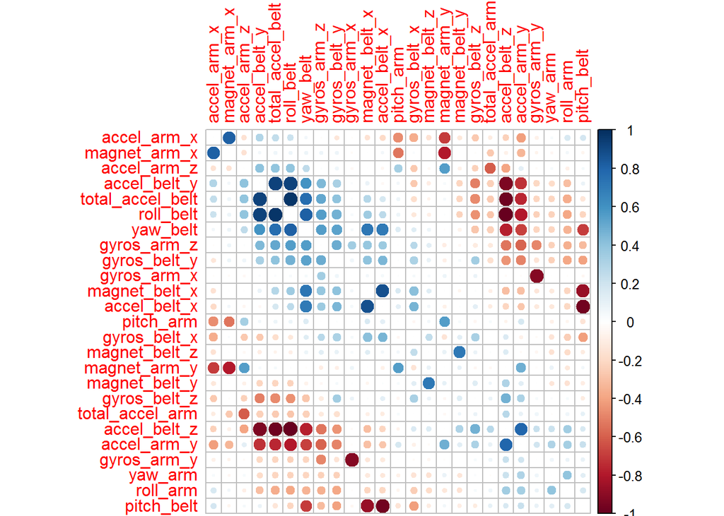

```r
library(corrplot)
corMatrix = cor(trainingSubSet1[,-53])
diag(corMatrix) = 0
corrplot(corMatrix[1:25,1:25],order="AOE",method="circle",sig.level=0.80,insig = "blank")
```

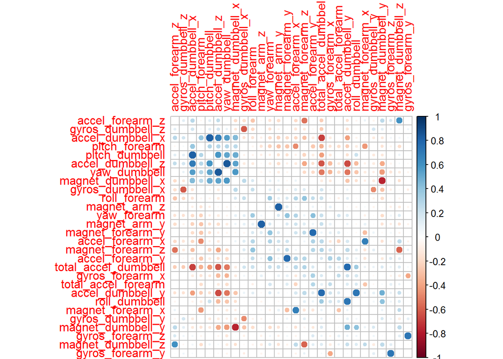

```r
corrplot(corMatrix[25:52,25:52],order="AOE",method="circle",sig.level=0.80,insig = "blank")
```

## Model Training

3 models *Rparts(WithPCA)* , *RParts(WithoutPCA)* and *RandomForest(WithPCA)* are evaludated. The models are then validated using test sets and most accurate models choosen.

### Using *RParts* with PCA on features

```r
library(caret)
preProc=preProcess(trainingSubSet1[,-53],method="pca", thresh=0.95)
trainPC=predict(preProc,trainingSubSet1[,-53])

if(file.exists("models/ModelFitRPartsPCA.rds")) {
    modelFitRPartsPCA<-readRDS("models/ModelFitRPartsPCA.rds")
} else{
    modelFitRPartsPCA<-train(trainingSubSet1$classe~.,method="rpart",data=trainPC)
    saveRDS(modelFitRPartsPCA,"models/ModelFitRPartsPCA.rds")
}

#print(modelFitRPartsPCA$finalModel)

testPC=predict(preProc,testSubSet1[,-53]) #Apply the same preprocessing to testset.
cf<-confusionMatrix(testSubSet1$classe, predict(modelFitRPartsPCA, testPC))
cf
```

```
## Confusion Matrix and Statistics
##
##           Reference
## Prediction   A   B   C   D   E
##          A 303   0   0  24   8
##          B 170   0   0  36  22
##          C 180   0   0  15  10
##          D 107   0   0  70  16
##          E 120   0   0  24  72
##
## Overall Statistics
##
##                Accuracy : 0.3781
##                  95% CI : (0.3503, 0.4065)
##     No Information Rate : 0.7477
##     P-Value [Acc > NIR] : 1
##
##                   Kappa : 0.1637
##  Mcnemar's Test P-Value : NA
##
## Statistics by Class:
##
##                      Class: A Class: B Class: C Class: D Class: E
## Sensitivity            0.3443       NA       NA  0.41420  0.56250
## Specificity            0.8923   0.8063   0.8258  0.87798  0.86273
## Pos Pred Value         0.9045       NA       NA  0.36269  0.33333
## Neg Pred Value         0.3147       NA       NA  0.89939  0.94173
## Prevalence             0.7477   0.0000   0.0000  0.14359  0.10875
## Detection Rate         0.2574   0.0000   0.0000  0.05947  0.06117
## Detection Prevalence   0.2846   0.1937   0.1742  0.16398  0.18352
## Balanced Accuracy      0.6183       NA       NA  0.64609  0.71261
```

### Use *RParts* with features that show a high correlation to the predicted value.

```r
library(caret)
cutTraining=trainingSubSet1[,c("total_accel_belt","roll_belt","classe")]
cutTest=testSubSet1[,c("total_accel_belt","roll_belt","classe")]
preProc=preProcess(cutTraining[,-3])
trainPC=predict(preProc,cutTraining[,-3])

if(file.exists("models/ModelFitRParts.rds")) {
    modelFitRParts<-readRDS("models/ModelFitRParts.rds")
} else {
    modelFitRParts<-train(trainingSubSet1$classe~.,method="rpart",data=trainPC)
    saveRDS(modelFitRParts,"models/ModelFitRParts.rds")
}

#print(modelFitRParts$finalModel)

testPC=predict(preProc,cutTest[,-3]) #Apply the same preprocessing to testset.
cf<-confusionMatrix(cutTest$classe, predict(modelFitRParts, testPC))
cf
```

```
## Confusion Matrix and Statistics
##
##           Reference
## Prediction   A   B   C   D   E
##          A 332   0   0   0   3
##          B 227   0   0   0   1
##          C 205   0   0   0   0
##          D 175   0   0   0  18
##          E  91   0   0   0 125
##
## Overall Statistics
##
##                Accuracy : 0.3883
##                  95% CI : (0.3603, 0.4168)
##     No Information Rate : 0.8751
##     P-Value [Acc > NIR] : 1
##
##                   Kappa : 0.1597
##  Mcnemar's Test P-Value : NA
##
## Statistics by Class:
##
##                      Class: A Class: B Class: C Class: D Class: E
## Sensitivity            0.3223       NA       NA       NA   0.8503
## Specificity            0.9796   0.8063   0.8258    0.836   0.9117
## Pos Pred Value         0.9910       NA       NA       NA   0.5787
## Neg Pred Value         0.1710       NA       NA       NA   0.9771
## Prevalence             0.8751   0.0000   0.0000    0.000   0.1249
## Detection Rate         0.2821   0.0000   0.0000    0.000   0.1062
## Detection Prevalence   0.2846   0.1937   0.1742    0.164   0.1835
## Balanced Accuracy      0.6510       NA       NA       NA   0.8810
```

### Use *Random Forest* with PCA on features

The following creates 2 Random forest models. The two models are based on diffirent training sets and thus will help reduce the out of sample error further.

**Following illustrates Model 1 constructed with trainingSubSet1**

```r
library(randomForest)
preProc1=preProcess(trainingSubSet1[,-53],method="pca", thresh=0.7)
trainPC1=predict(preProc1,trainingSubSet1[,-53])

if(file.exists("models/ModelFitRForest1.rds")) {
    modelFitRForest1<-readRDS("models/ModelFitRForest1.rds")
} else {
    modelFitRForest1<-train(trainingSubSet1$classe~.,method="rf",data=trainPC1)
    saveRDS(modelFitRForest1,"models/ModelFitRForest1.rds")
}

print(modelFitRForest1$finalModel)
```

```
##
## Call:
##  randomForest(x = x, y = y, mtry = param$mtry)
##                Type of random forest: classification
##                      Number of trees: 500
## No. of variables tried at each split: 2
##
##         OOB estimate of  error rate: 7.86%
## Confusion matrix:
##      A    B    C    D    E class.error
## A 2119   34   34   33   12  0.05062724
## B   51 1386   56   12   14  0.08755760
## C   38   41 1252   28   10  0.08546384
## D   27   11   77 1160   12  0.09867910
## E   32   39   27   29 1316  0.08801109
```

```r
testPC1=predict(preProc1,testSubSet1[,-53]) #Apply the same preprocessing to testset.
cf1<-confusionMatrix(testSubSet1$classe, predict(modelFitRForest1, testPC1))
cf1
```

```
## Confusion Matrix and Statistics
##
##           Reference
## Prediction   A   B   C   D   E
##          A 323   3   5   4   0
##          B  11 207  10   0   0
##          C   8   6 187   2   2
##          D   5   2   8 176   2
##          E   1  13   6   8 188
##
## Overall Statistics
##
##                Accuracy : 0.9184
##                  95% CI : (0.9013, 0.9334)
##     No Information Rate : 0.2957
##     P-Value [Acc > NIR] : < 2.2e-16
##
##                   Kappa : 0.8967
##  Mcnemar's Test P-Value : 0.0004712
##
## Statistics by Class:
##
##                      Class: A Class: B Class: C Class: D Class: E
## Sensitivity            0.9282   0.8961   0.8657   0.9263   0.9792
## Specificity            0.9855   0.9778   0.9813   0.9828   0.9716
## Pos Pred Value         0.9642   0.9079   0.9122   0.9119   0.8704
## Neg Pred Value         0.9703   0.9747   0.9702   0.9858   0.9958
## Prevalence             0.2957   0.1963   0.1835   0.1614   0.1631
## Detection Rate         0.2744   0.1759   0.1589   0.1495   0.1597
## Detection Prevalence   0.2846   0.1937   0.1742   0.1640   0.1835
## Balanced Accuracy      0.9568   0.9370   0.9235   0.9545   0.9754
```

**Following illustrates model 2 constructed with trainingSubSet2**

```r
library(randomForest)
preProc2=preProcess(trainingSubSet2[,-53],method="pca", thresh=0.7)
trainPC2=predict(preProc2,trainingSubSet2[,-53])

if(file.exists("models/ModelFitRForest2.rds")) {
    modelFitRForest2<-readRDS("models/ModelFitRForest2.rds")
} else {
    modelFitRForest2<-train(trainingSubSet2$classe~.,method="rf",data=trainPC2)
    saveRDS(modelFitRForest2,"models/ModelFitRForest2.rds")
}

print(modelFitRForest2$finalModel)
```

```
##
## Call:
##  randomForest(x = x, y = y, mtry = param$mtry)
##                Type of random forest: classification
##                      Number of trees: 500
## No. of variables tried at each split: 2
##
##         OOB estimate of  error rate: 29.53%
## Confusion matrix:
##     A   B   C   D   E class.error
## A 275  17  23  15   4   0.1766467
## B  22 146  23  14  22   0.3568282
## C  44  15 128  11   7   0.3756098
## D  18  17  16 136   6   0.2953368
## E   9  33  19  12 143   0.3379630
```

```r
testPC2=predict(preProc2,testSubSet1[,-53]) #Apply the same preprocessing to testset.
cf2<-confusionMatrix(testSubSet1$classe, predict(modelFitRForest2, testPC2))
cf2
```

```
## Confusion Matrix and Statistics
##
##           Reference
## Prediction   A   B   C   D   E
##          A 278  10  22  22   3
##          B  22 155  26   6  19
##          C  36  11 135  15   8
##          D  29  17  18 125   4
##          E   9  28  16  10 153
##
## Overall Statistics
##
##                Accuracy : 0.7188
##                  95% CI : (0.6921, 0.7443)
##     No Information Rate : 0.3178
##     P-Value [Acc > NIR] : < 2.2e-16
##
##                   Kappa : 0.6427
##  Mcnemar's Test P-Value : 0.0007321
##
## Statistics by Class:
##
##                      Class: A Class: B Class: C Class: D Class: E
## Sensitivity            0.7433   0.7014   0.6221   0.7022   0.8182
## Specificity            0.9290   0.9236   0.9271   0.9319   0.9364
## Pos Pred Value         0.8299   0.6798   0.6585   0.6477   0.7083
## Neg Pred Value         0.8860   0.9305   0.9156   0.9461   0.9646
## Prevalence             0.3178   0.1878   0.1844   0.1512   0.1589
## Detection Rate         0.2362   0.1317   0.1147   0.1062   0.1300
## Detection Prevalence   0.2846   0.1937   0.1742   0.1640   0.1835
## Balanced Accuracy      0.8362   0.8125   0.7746   0.8171   0.8773
```

# Use the best model and generate results.

Predict results based on the validation set.

```r
validationPC1=predict(preProc1,validationSubSetNoFactors) #Apply the same preprocessing to testset.
results1=predict(modelFitRForest1,validationPC1)

validationPC2=predict(preProc2,validationSubSetNoFactors) #Apply the same preprocessing to testset.
results2=predict(modelFitRForest2,validationPC2)

results1
```

```
##  [1] B A A C A E D A A A A C B A E E A B D B
## Levels: A B C D E
```

```r
results2
```

```
##  [1] A A A A A E D B A A A C B A E E A B D B
## Levels: A B C D E
```

These results are evaluted with the actual results. result1 and result 2 together gave a accuracy of 100% in 2 trials.

## Features dropped as predictors

The following is the list of columsn that were null/NA in validation set and thus were dropped from the list of candidate kurtosis_roll_belt, kurtosis_picth_belt, kurtosis_yaw_belt, skewness_roll_belt, skewness_roll_belt.1, skewness_yaw_belt, max_roll_belt, max_picth_belt, max_yaw_belt, min_roll_belt, min_pitch_belt, min_yaw_belt, amplitude_roll_belt, amplitude_pitch_belt, amplitude_yaw_belt, var_total_accel_belt, avg_roll_belt, stddev_roll_belt, var_roll_belt, avg_pitch_belt, stddev_pitch_belt, var_pitch_belt, avg_yaw_belt, stddev_yaw_belt, var_yaw_belt, var_accel_arm, avg_roll_arm, stddev_roll_arm, var_roll_arm, avg_pitch_arm, stddev_pitch_arm, var_pitch_arm, avg_yaw_arm, stddev_yaw_arm, var_yaw_arm, kurtosis_roll_arm, kurtosis_picth_arm, kurtosis_yaw_arm, skewness_roll_arm, skewness_pitch_arm, skewness_yaw_arm, max_roll_arm, max_picth_arm, max_yaw_arm, min_roll_arm, min_pitch_arm, min_yaw_arm, amplitude_roll_arm, amplitude_pitch_arm, amplitude_yaw_arm, kurtosis_roll_dumbbell, kurtosis_picth_dumbbell, kurtosis_yaw_dumbbell, skewness_roll_dumbbell, skewness_pitch_dumbbell, skewness_yaw_dumbbell, max_roll_dumbbell, max_picth_dumbbell, max_yaw_dumbbell, min_roll_dumbbell, min_pitch_dumbbell, min_yaw_dumbbell, amplitude_roll_dumbbell, amplitude_pitch_dumbbell, amplitude_yaw_dumbbell, var_accel_dumbbell, avg_roll_dumbbell, stddev_roll_dumbbell, var_roll_dumbbell, avg_pitch_dumbbell, stddev_pitch_dumbbell, var_pitch_dumbbell, avg_yaw_dumbbell, stddev_yaw_dumbbell, var_yaw_dumbbell, kurtosis_roll_forearm, kurtosis_picth_forearm, kurtosis_yaw_forearm, skewness_roll_forearm, skewness_pitch_forearm, skewness_yaw_forearm, max_roll_forearm, max_picth_forearm, max_yaw_forearm, min_roll_forearm, min_pitch_forearm, min_yaw_forearm, amplitude_roll_forearm, amplitude_pitch_forearm, amplitude_yaw_forearm, var_accel_forearm, avg_roll_forearm, stddev_roll_forearm, var_roll_forearm, avg_pitch_forearm, stddev_pitch_forearm, var_pitch_forearm, avg_yaw_forearm, stddev_yaw_forearm, var_yaw_forearm

## Understanding potential model fits by plotting high correlation feaures

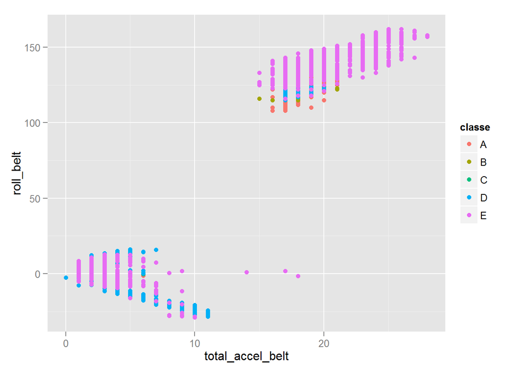

```r
library(ggplot2)
ggplot(data=trainingSubSet1, aes(x=total_accel_belt, y=roll_belt)) +
    geom_point(aes(color=classe))
```

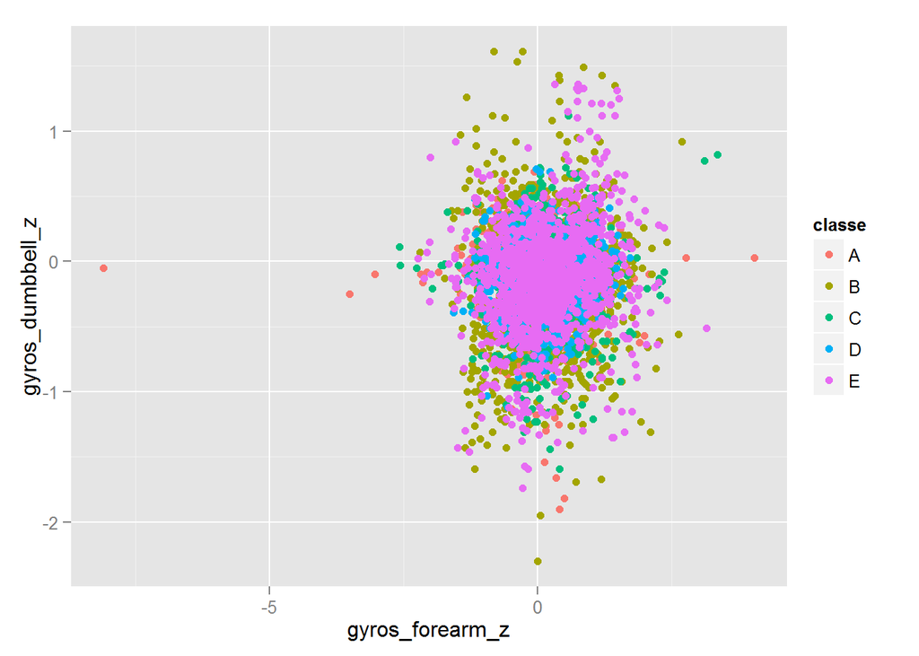

```r
ggplot(data=trainingSubSet1, aes(x=gyros_forearm_z, y=gyros_dumbbell_z)) +
    geom_point(aes(color=classe))
```

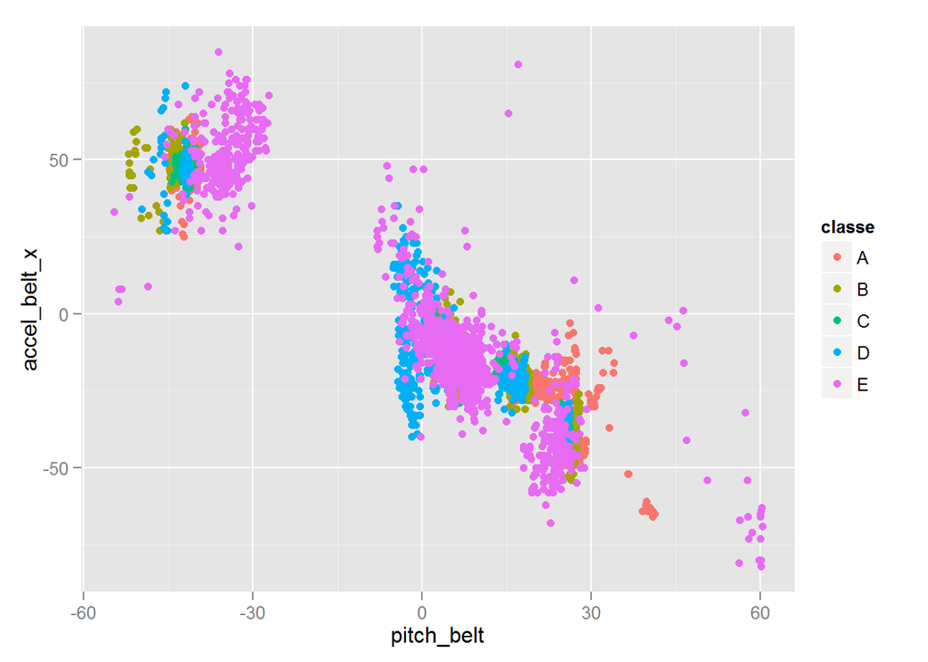

```r
ggplot(data=trainingSubSet1, aes(x=pitch_belt, y=accel_belt_x)) +
    geom_point(aes(color=classe))
```

### Testing the 2 random forest models

```r
# Test 2 models with TestSubSet2
testPC=predict(preProc1,testSubSet2[,-53]) #Apply the same preprocessing to testset.
confusionMatrix(testSubSet2$classe, predict(modelFitRForest1, testPC))
```

```
## Confusion Matrix and Statistics
##
##           Reference
## Prediction   A   B   C   D   E
##          A 321   5   4   3   2
##          B  11 206   7   2   2
##          C   6   5 191   2   1
##          D   6   0  17 168   1
##          E   3   4   3   6 200
##
## Overall Statistics
##
##                Accuracy : 0.9235
##                  95% CI : (0.9068, 0.938)
##     No Information Rate : 0.2951
##     P-Value [Acc > NIR] : < 2.2e-16
##
##                   Kappa : 0.9031
##  Mcnemar's Test P-Value : 0.009815
##
## Statistics by Class:
##
##                      Class: A Class: B Class: C Class: D Class: E
## Sensitivity            0.9251   0.9364   0.8604   0.9282   0.9709
## Specificity            0.9831   0.9770   0.9853   0.9759   0.9835
## Pos Pred Value         0.9582   0.9035   0.9317   0.8750   0.9259
## Neg Pred Value         0.9691   0.9852   0.9681   0.9868   0.9938
## Prevalence             0.2951   0.1871   0.1888   0.1539   0.1752
## Detection Rate         0.2730   0.1752   0.1624   0.1429   0.1701
## Detection Prevalence   0.2849   0.1939   0.1743   0.1633   0.1837
## Balanced Accuracy      0.9541   0.9567   0.9228   0.9520   0.9772
```

```r
testPC=predict(preProc2,testSubSet2[,-53]) #Apply the same preprocessing to testset.
confusionMatrix(testSubSet2$classe, predict(modelFitRForest2, testPC))
```

```
## Confusion Matrix and Statistics
##
##           Reference
## Prediction   A   B   C   D   E
##          A 289  12  20  13   1
##          B  22 153  25  12  16
##          C  22  14 147  11  11
##          D  18  12  26 127   9
##          E  12  28  18  12 146
##
## Overall Statistics
##
##                Accuracy : 0.733
##                  95% CI : (0.7067, 0.7581)
##     No Information Rate : 0.3087
##     P-Value [Acc > NIR] : < 2.2e-16
##
##                   Kappa : 0.6612
##  Mcnemar's Test P-Value : 0.001997
##
## Statistics by Class:
##
##                      Class: A Class: B Class: C Class: D Class: E
## Sensitivity            0.7961   0.6986   0.6229   0.7257   0.7978
## Specificity            0.9434   0.9216   0.9383   0.9351   0.9295
## Pos Pred Value         0.8627   0.6711   0.7171   0.6615   0.6759
## Neg Pred Value         0.9120   0.9304   0.9083   0.9512   0.9615
## Prevalence             0.3087   0.1862   0.2007   0.1488   0.1556
## Detection Rate         0.2457   0.1301   0.1250   0.1080   0.1241
## Detection Prevalence   0.2849   0.1939   0.1743   0.1633   0.1837
## Balanced Accuracy      0.8698   0.8101   0.7806   0.8304   0.8637
```

```r
# Test 2 models with TestSubSet3
testPC=predict(preProc1,testSubSet3[,-53]) #Apply the same preprocessing to testset.
confusionMatrix(testSubSet3$classe, predict(modelFitRForest1, testPC))
```

```
## Confusion Matrix and Statistics
##
##           Reference
## Prediction   A   B   C   D   E
##          A 327   1   5   2   0
##          B  10 201  14   0   3
##          C   3   6 191   3   2
##          D   6   1  10 174   2
##          E   1   4   4   3 205
##
## Overall Statistics
##
##                Accuracy : 0.9321
##                  95% CI : (0.9162, 0.9458)
##     No Information Rate : 0.2946
##     P-Value [Acc > NIR] : < 2e-16
##
##                   Kappa : 0.914
##  Mcnemar's Test P-Value : 0.03078
##
## Statistics by Class:
##
##                      Class: A Class: B Class: C Class: D Class: E
## Sensitivity            0.9424   0.9437   0.8527   0.9560   0.9670
## Specificity            0.9904   0.9720   0.9853   0.9809   0.9876
## Pos Pred Value         0.9761   0.8816   0.9317   0.9016   0.9447
## Neg Pred Value         0.9763   0.9874   0.9661   0.9919   0.9927
## Prevalence             0.2946   0.1808   0.1902   0.1545   0.1800
## Detection Rate         0.2776   0.1706   0.1621   0.1477   0.1740
## Detection Prevalence   0.2844   0.1935   0.1740   0.1638   0.1842
## Balanced Accuracy      0.9664   0.9578   0.9190   0.9685   0.9773
```

```r
testPC=predict(preProc2,testSubSet3[,-53]) #Apply the same preprocessing to testset.
confusionMatrix(testSubSet3$classe, predict(modelFitRForest2, testPC))
```

```
## Confusion Matrix and Statistics
##
##           Reference
## Prediction   A   B   C   D   E
##          A 295  12  15   9   4
##          B  17 164  23   6  18
##          C  25  13 148  13   6
##          D  28   8  18 130   9
##          E   5  29  14  10 159
##
## Overall Statistics
##
##                Accuracy : 0.7606
##                  95% CI : (0.7352, 0.7847)
##     No Information Rate : 0.3141
##     P-Value [Acc > NIR] : < 2e-16
##
##                   Kappa : 0.6959
##  Mcnemar's Test P-Value : 0.01102
##
## Statistics by Class:
##
##                      Class: A Class: B Class: C Class: D Class: E
## Sensitivity            0.7973   0.7257   0.6789   0.7738   0.8112
## Specificity            0.9505   0.9328   0.9406   0.9376   0.9409
## Pos Pred Value         0.8806   0.7193   0.7220   0.6736   0.7327
## Neg Pred Value         0.9110   0.9347   0.9281   0.9614   0.9615
## Prevalence             0.3141   0.1919   0.1851   0.1426   0.1664
## Detection Rate         0.2504   0.1392   0.1256   0.1104   0.1350
## Detection Prevalence   0.2844   0.1935   0.1740   0.1638   0.1842
## Balanced Accuracy      0.8739   0.8292   0.8098   0.8557   0.8761
```

### Challanges and Issues

- Training Random Forest takes a lot of time.
- Explore if further data transformation can reduce model construction times without compromizing accuracy.

### Links and Notes

[groupware.les](http://groupware.les.inf.puc-rio.br/har) [John Hopkins Data Science Specialization](https://www.coursera.org/specializations/jhudatascience)